# Final Exam (100 points + 10 points Bonus)

# Part 2: Exploratory statistics (20 points)

For all questions below, we will use the cleaned `census` data frame derived from Part 1 Question 6.

1. (5 points) There are several variables which count the percentage of respondents in various age categories (they all start with `pct_Pop_`). (Hint: you may access these columns using `grep()`.) Use these to determine, for each census tract, the percentages of the population that are less than 5 years old, and append these values in a new column called `pct_Pop_0_4_ACS_09_13` to the `census` data frame. Then, use this new column, along with the existing `Tot_Population_ACS_09_13` column, to determine the number of 0-4 year olds in each state. Which state has the highest number, and what is its value?

```r
# Assuming pct_Rel_Under_6_ACS_09_13 is a close approximation for under 5
census_clean$pct_Pop_0_4_ACS_09_13 <- census_clean$pct_Rel_Under_6_ACS_09_13

# Calculate the number of 0-4 year olds using the total population
census_clean$Num_0_4 <- census_clean$Tot_Population_ACS_09_13 * census_clean$pct_Pop_0_4_ACS_09_13 / 100

# Aggregate this number by state to find the total per state
total_0_4_by_state <- aggregate(Num_0_4 ~ State_name, data = census_clean, FUN = sum)

# State with the highest number of 0-4 year-olds
state_with_max_0_4 <- total_0_4_by_state[which.max(total_0_4_by_state$Num_0_4), ]
state_with_max_0_4
```

```
##   State_name Num_0_4
## 5 California 9117359
```

2. (5 points) Using your answer from the last question, determine the percentage of 0-4 year olds in each state. Which state has the highest percentage, and what is its value?

```r
# Aggregate the total population per state
total_population_by_state <- aggregate(Tot_Population_ACS_09_13 ~ State_name, data = census, sum)

# Aggregate the number of 0-4 year olds per state
total_0_4_by_state <- aggregate(Num_0_4 ~ State_name, data = census_clean, sum)

# Merge total 0-4 year old data with total population data
merged_data <- merge(total_population_by_state, total_0_4_by_state, by = "State_name")

# Calculate the percentage of 0-4 year olds in each state
merged_data$pct_0_4 = (merged_data$Num_0_4 / merged_data$Tot_Population_ACS_09_13) * 100

# Find the state with the highest percentage of 0-4 year olds
state_with_highest_percentage_0_4 <- merged_data[which.max(merged_data$pct_0_4), ]
state_with_highest_percentage_0_4
```

```
##    State_name Tot_Population_ACS_09_13  Num_0_4  pct_0_4
## 45       Utah                  2813673 838869.3 29.81403
```

3. (5 points) Calculate the correlation between each of the numeric variables, columns 8 through 31 of the `census` data frame. Which two variables have the highest positive correlation? Which two variables have the lowest negative correlation? Do these relationships make sense?

```r
# Calculate the correlation matrix for the numeric variables
correlation_matrix <- cor(census_clean[, 8:31], use = "pairwise.complete.obs")

# Extract the highest positive and lowest negative correlation
max_correlation_value <- max(correlation_matrix[lower.tri(correlation_matrix)])
min_correlation_value <- min(correlation_matrix[lower.tri(correlation_matrix)])

# Identify the indices of these maximum and minimum values
max_correlation_indices <- which(correlation_matrix == max_correlation_value, arr.ind = TRUE)
min_correlation_indices <- which(correlation_matrix == min_correlation_value, arr.ind = TRUE)

# Extract the variable names corresponding to these indices
highest_positive_correlation_vars <- names(census_clean[, 8:31])[max_correlation_indices]
lowest_negative_correlation_vars <- names(census_clean[, 8:31])[min_correlation_indices]

list(highest_correlation = highest_positive_correlation_vars, lowest_correlation = lowest_negative_correlation_vars)
```

```
## $highest_correlation
## [1] "pct_College_ACS_09_13" "Med_HHD_Inc_ACS_09_13" "Med_HHD_Inc_ACS_09_13"
## [4] "pct_College_ACS_09_13"
##
## $lowest_correlation
## [1] "pct_Single_Unit_ACS_09_13"    "pct_Renter_Occp_HU_ACS_09_13"
## [3] "pct_Renter_Occp_HU_ACS_09_13" "pct_Single_Unit_ACS_09_13"
```

4. (2 points) Plot a histogram of `Med_House_value_ACS_09_13`, and label the axes appropriately. See that small bump at the value 1000001? This is a due to a common practice in public data sets of “top-coding”, i.e., censoring unusually large values to protect the anonymity of survey respondents.

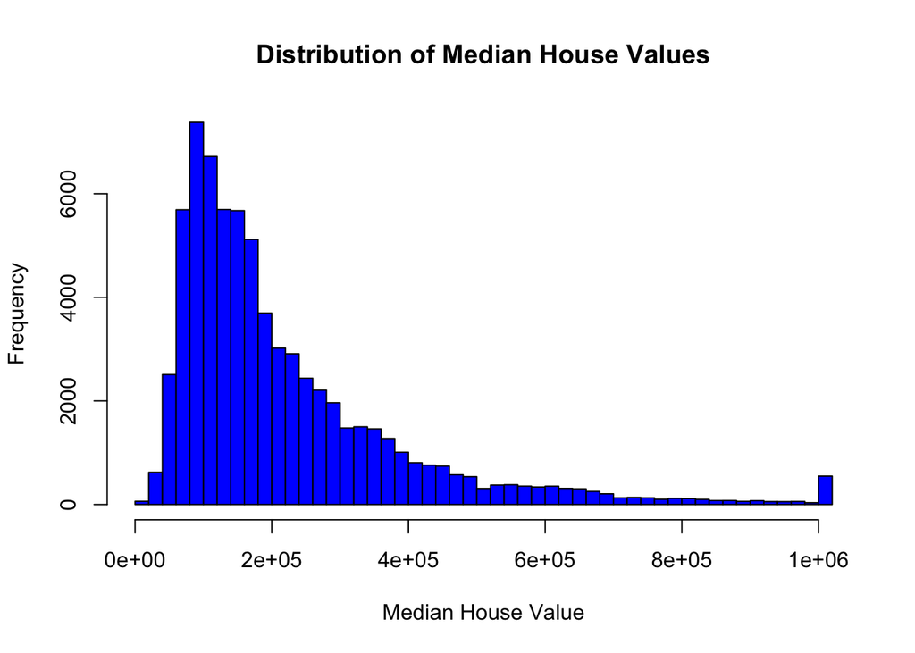

```r
# Plotting the histogram of median house values
hist(census_clean$Med_House_value_ACS_09_13, breaks = 50, main = "Distribution of Median House Values",
     xlab = "Median House Value", ylab = "Frequency", col = "blue")
```

5. (3 points) It is possible that the tracts that have been top-coded differ significantly from the other tracts, in other ways than the median house value. The following code computes a t-test between two groups of census tracts, on any given variable. The two groups being compared are: all tracts with median house value equal to the max (1000001) and all tracts with median house value less than the max (<1000001). It then returns a p-value for the test. Note that a lower p-value means a more significant difference between top-coded and non-top-coded tracts, according to the variable in question.

```r
my.test = function(var) {
  group = census$Med_House_value_ACS_09_13 == 1000001
  p.val = t.test(var[group], var[!group])$p.value
  return(p.val)
}
```

Apply the function `my.test()` to the variables in columns 10 through 31 of the `census` data frame. What are the two smallest p-values, and which variables do these correspond to? Does this make sense?

```r
# Apply the t-test function to variables in the specified columns
p_values <- sapply(census_clean[, 10:31], my.test)

# Find the two smallest p-values and their corresponding variable names
smallest_p_values <- sort(p_values)[1:2]
names(smallest_p_values)
```

```
## [1] "pct_NH_Blk_alone_ACS_09_13" "pct_Hispanic_ACS_09_13"
```

# Part 3: Sampling and plotting (30 points)

Plotting data of this size is tricky just because the sheer number of datapoints. For instance, you can try on your own to `plot(census)` to see your computer wheeze, cough, crash and burn. In this part, we will write a suite of functions that allow you to more efficiently plot relationships between pairs of variables in your dataset.

1. (10 points) Write a function `plot.sample()` that takes in five arguments: `x`, `y`, `nsample`, `xlab`, and `ylab`. The first two arguments are variables to be plotted. The third is the number of points to be randomly sampled, with a default of 500. (Hence, if `x` and `y` are vectors of length, say, 5000, then a random 500 of the total 5000 x-y pairs will be plotted, by default.) The last two are the x and y labels, both with defaults of `""` (the empty string). A few notes:
- check that `x,y` have the same length, and if not, throw an error (using `stop()` or `stopifnot()`);
- check that the number of requested samples does not exceed the total number of data points, otherwise throw an error;
- the plot should not have a title.

```r
plot.sample <- function(x, y, nsample = 500, xlab = "", ylab = "") {
    # Check if x and y have the same length
    stopifnot(length(x) == length(y))

    # Check if nsample exceeds the number of data points
    if (nsample > length(x)) {
        stop("Requested sample size exceeds the number of available data points.")
    }

    # Sample the data
    indices <- sample(1:length(x), nsample)
    x_sampled <- x[indices]
    y_sampled <- y[indices]

    # Plot the data
    plot(x_sampled, y_sampled, xlab = xlab, ylab = ylab, pch = 19, col = rgb(0, 0, 1, 0.5), main = "")
}
```

After writing this function, you can try it out using the following code (specify `eval=TRUE`).

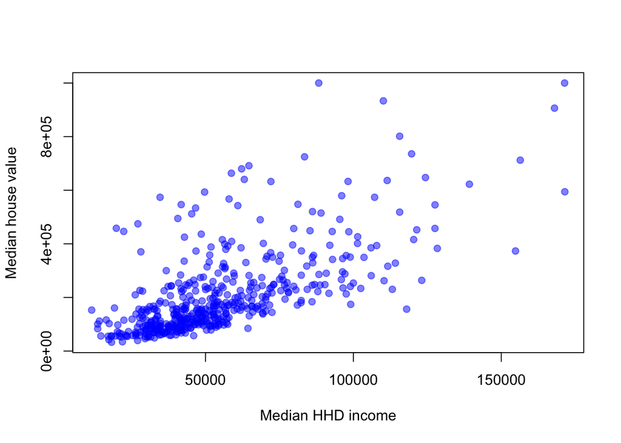

```r
plot.sample(census$Med_HHD_Inc_ACS_09_13, census$Med_House_value_ACS_09_13,
            xlab="Median HHD income", ylab="Median house value")
```

2. (10 points) Next, write a function `add.lineartrend.info()`, which is designed to be called after `plot.sample()`. This takes as input `x`, `y` for variables that already appear on the x-and y-axes, and does two things:
- adds the best fit line (produced by `lm()`) function in red, and with twice the default width (using the `lwd=2` option);
- adds a title to the plot with the numeric correlation of the two variables, using 3 significant digits (see `signif()`).

```r
add.lineartrend.info <- function(x, y) {
    valid_data <- complete.cases(x, y)
    x <- x[valid_data]
    y <- y[valid_data]

    if (length(x) > 1) {
        # Fit a linear model
        model <- lm(y ~ x)
        abline(model, col = "red", lwd = 2)

        # Calculate and display the correlation coefficient
        corr_coef <- cor(x, y)
        title(sub = paste("Correlation:", signif(corr_coef, 3)))
    } else {
        title(sub = "Correlation: NA (not enough data)")
    }
}
```

To reiterate, this function assumes there is a plot already in place; it simply adds the line and the title. Again, after writing this function, you can try it out using the following code (specify `eval=TRUE`).

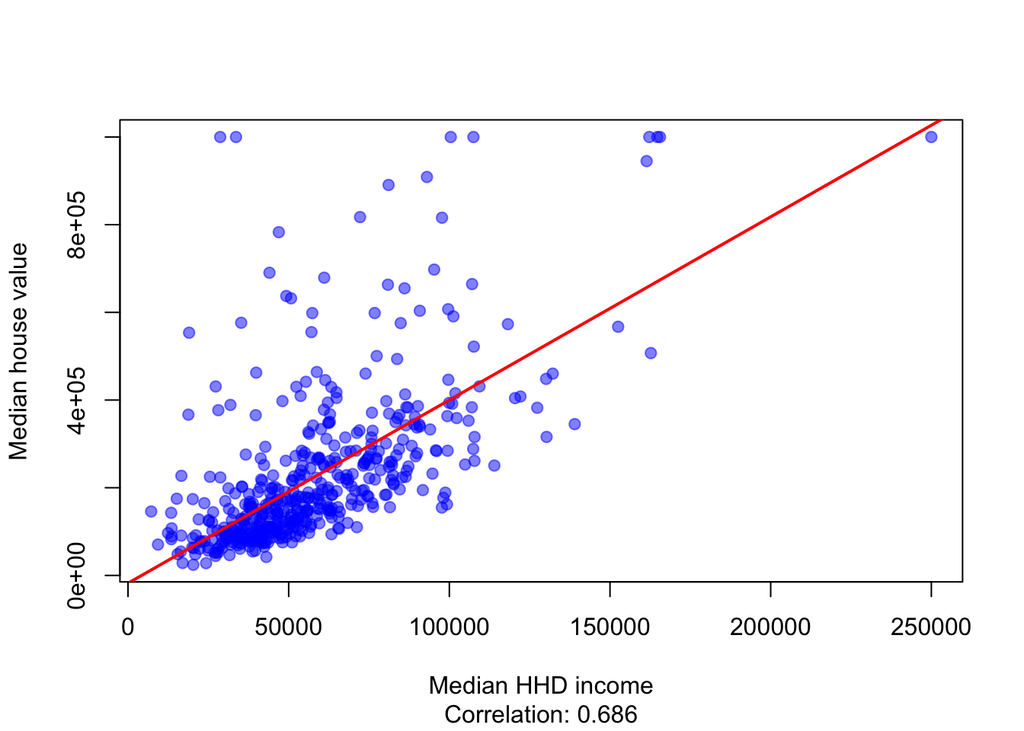

```r
plot.sample(census$Med_HHD_Inc_ACS_09_13, census$Med_House_value_ACS_09_13,
            xlab="Median HHD income", ylab="Median house value")
add.lineartrend.info(census$Med_HHD_Inc_ACS_09_13, census$Med_House_value_ACS_09_13)
```

3. (10 points) Lastly, write a function `plot.all()` which takes as input `dataset` and `nsample`, a data frame, and the number of points to be sampled. This function will mimick the behavior of `plot()` when applied to data frames. In other words, if `dataset` has `p` columns, then `plot.all()` should produce a `p` by `p` retangular grid of plots, where the plot in entry `i`, `j` of the grid uses column `i` for the x-axis data, and column `j` for the y-axis data. Some notes:
- in each grid entry, the plot should be produced by your previous function, `plot.sample()`;
- in each grid entry, a best fit line should be added and the correlation should be displayed in the title, using your previous function, `add.lineartrend.info()`;
- in the diagonal grid entries, instead of plotting the data (and adding linear trend info), simply use `text()` to write the variable names in the middle of otherwise empty plots.

A code template for `plot.all()` is found below. (Hint: using a `for()` loop for the grid entries is perfectly fine.) Fill it out, and then run the code that follows (specify `eval=TRUE`) to plot the pairwise relationships between the 4 census variables `Med_HHD_Inc_ACS_09_13`, `Med_House_value_ACS_09_13`, `pct_College_ACS_09_13`, and `Mail_Return_Rate_CEN_2010`. Comment on the results; do the relationships make sense to you?

```r
plot.all = function(dataset, nsample=500) {
  p = ncol(dataset)
  orig.par = par()

  # Set the margins, and plotting grid
  par(mar=c(2,2,2,2))
  par(mfrow=c(p,p))

  # TODO: your plotting code goes here
    for (i in 1:p) {
        for (j in 1:p) {
            if (i == j) {
                # Plot variable names on the diagonal
                plot(1, type = "n", axes = FALSE, xlab = "", ylab = "", main = "")
                text(1, 1, names(dataset)[i], cex = 1.2)
            } else {
                # Sample and plot data
                plot.sample(dataset[[i]], dataset[[j]], nsample, xlab = names(dataset)[i], ylab = names(dataset)[j])
                add.lineartrend.info(dataset[[i]], dataset[[j]])
            }
        }
    }
  # Reset the margins, and plotting grid
  par(mar=orig.par$mar)
  par(mfrow=orig.par$mfrow)
}
```

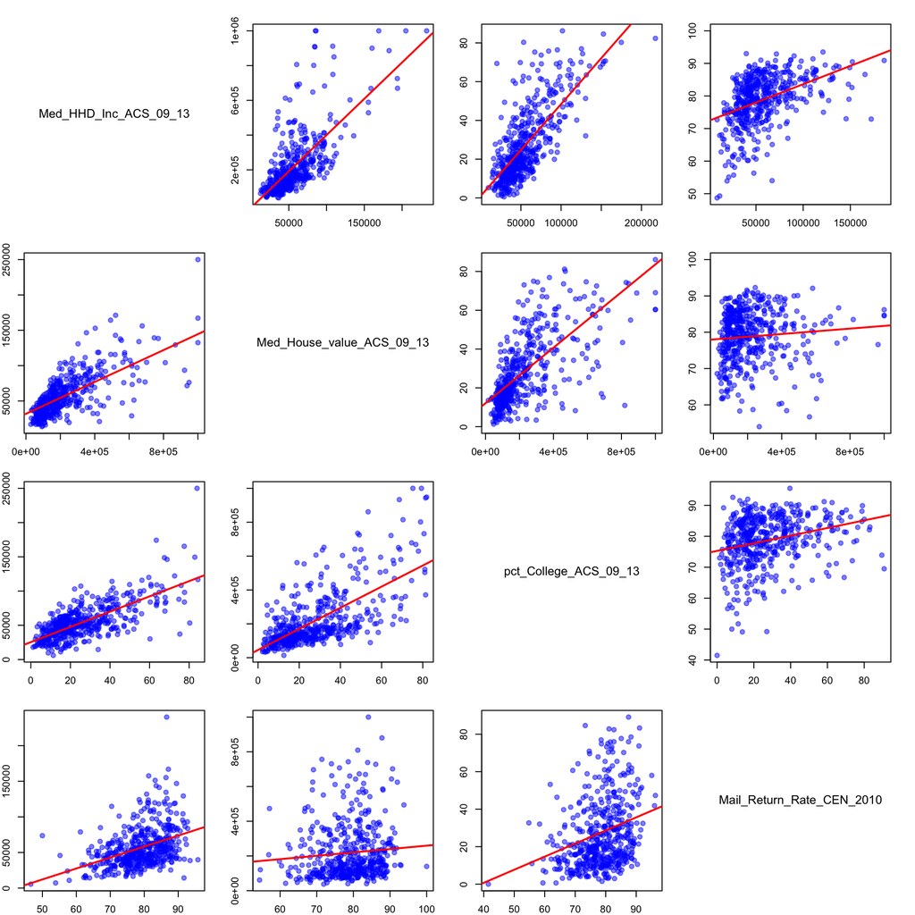

```r
mydat = census[,c("Med_HHD_Inc_ACS_09_13", "Med_House_value_ACS_09_13",
                  "pct_College_ACS_09_13","Mail_Return_Rate_CEN_2010")]
plot.all(mydat)
```

# Part 4: Permute away! (25 points + 10 points Bonus)

Here, we will use what is called *permutation test* to answer the following question: are the linear regression coefficients between two different states substantially different? Note: a permutation test is a fairly advanced statistical technique, but not much statistical knowledge is required to answer this question. For a bit more (optional) discussion on the permutation test, see the end of this part.

```r
# Extract rows for Virginia and West Virginia
census.vw <- subset(census, State_name %in% c("Virginia", "West Virginia"))

# Verify the number of rows
nrow(census.vw)
```

```
## [1] 2392
```

2. (6 points) Now perform two separate linear regressions using `census.vw`. The first is a linear regression of `Mail_Return_Rate_CEN_2010` (as the response) on `pct_NH_White_alone_ACS_09_13` and `pct_Renter_Occp_HU_ACS_09_13` (as the predictors), using only the tracts in Virginia; the second is again a linear regression of `Mail_Return_Rate_CEN_2010` (as the response) on `pct_NH_White_alone_ACS_09_13` and `pct_Renter_Occp_HU_ACS_09_13` (as the predictors), but now using only the tracts in West Virginia. Ignoring the intercept terms, each linear regression model here gives you two coefficients (one for `pct_NH_White_alone_ACS_09_13` and one for `pct_Renter_Occp_HU_ACS_09_13`). Compare the two sets of coefficients. Are they the same?

```r
# Filter data for each state
virginia_data <- subset(census.vw, State_name == "Virginia")
west_virginia_data <- subset(census.vw, State_name == "West Virginia")

# Linear regression for Virginia
model_va <- lm(Mail_Return_Rate_CEN_2010 ~ pct_NH_White_alone_ACS_09_13 + pct_Renter_Occp_HU_ACS_09_13, data=virginia_data)
coefficients_va <- coef(model_va)[2:3]

# Linear regression for West Virginia
model_wv <- lm(Mail_Return_Rate_CEN_2010 ~ pct_NH_White_alone_ACS_09_13 + pct_Renter_Occp_HU_ACS_09_13, data=west_virginia_data)
coefficients_wv <- coef(model_wv)[2:3]

# Output the coefficients for comparison
list(Virginia = coefficients_va, West_Virginia = coefficients_wv)
```

```
## $Virginia
## pct_NH_White_alone_ACS_09_13 pct_Renter_Occp_HU_ACS_09_13
##                   0.07197805                  -0.16366500
##
## $West_Virginia
## pct_NH_White_alone_ACS_09_13 pct_Renter_Occp_HU_ACS_09_13
##                  -0.02169616                  -0.08365703
```

3. (6 points) Even though the two coefficients for Virginia and West Virginia may be different, it is hard to tell just *how different* they are. To help answer this question, we will look at the linear regression coefficients if we were to randomly scramble census tracts between Virginia and West Virginia, then refit the linear regression models. This is the idea behind a *permutation test*. Vaguely speaking, if the two sets of coefficients were truly the same, then shuffling the labels should have no real effect on our estimated coefficients. First, make a copy of `census.vw` called `census.vw.perm`. Then, randomly permute the entries in `census.vw.perm$State_name`. (Hint: recall the function `sample()`.) Once this is done, rerun the two regression models from Part 4 Question 2 using `census.vw.perm`, and report the coefficients for Virginia, and for West Virginia. What are their values now? Are the differences between coefficients for Virginia and West Virginia much smaller than they were in Part 4 Question 2?

```r
# Shuffle the state labels and refit models
census.vw.perm <- census.vw
census.vw.perm$State_name <- sample(census.vw.perm$State_name)

# Repeat the regression for shuffled data
model_va_perm <- lm(Mail_Return_Rate_CEN_2010 ~ pct_NH_White_alone_ACS_09_13 + pct_Renter_Occp_HU_ACS_09_13, data=subset(census.vw.perm, State_name == "Virginia"))
model_wv_perm <- lm(Mail_Return_Rate_CEN_2010 ~ pct_NH_White_alone_ACS_09_13 + pct_Renter_Occp_HU_ACS_09_13, data=subset(census.vw.perm, State_name == "West Virginia"))

# Coefficients from the permuted data
coefficients_va_perm <- coef(model_va_perm)[2:3]
coefficients_wv_perm <- coef(model_wv_perm)[2:3]

# Output the permuted coefficients
list(Virginia_Perm = coefficients_va_perm, West_Virginia_Perm = coefficients_wv_perm)
```

```
## $Virginia_Perm
## pct_NH_White_alone_ACS_09_13 pct_Renter_Occp_HU_ACS_09_13
##                 0.0007678665                -0.1711484531
##
## $West_Virginia_Perm
## pct_NH_White_alone_ACS_09_13 pct_Renter_Occp_HU_ACS_09_13
##                 -0.005671092                 -0.194553534
```

4. (10 points) You will write a function to encapsulate the tasks you performed in the previous questions. The function will be called `reg.coef()`, and it will take in five arguments:
- `census.subset`, a data frame, whose rows are a subset of the full `census` data frame;
- `x1`, `x2`, two strings that match column names in `census.subset`, representing predictor variables for the regression;
- `y`, another string that matches a column name in `census.subset`, representing a response variable for the regression;
- `shuffle`, a Boolean variable, whose default value is `FALSE`.

Your function should perform the following. If `shuffle` is `TRUE`, then the entries in `census.subset$State_name` are randomly permuted. If `shuffle` is `FALSE`, then this step is not performed (and `census.subset$State_name` is left alone). Next, for each state in the `census.subset` data frame, run a regression of the response, represented by `y`, on predictor variables, represented by `x1` and `x2`. (Hint: you may create the formula in `lm()` using `paste()`.) A matrix with 2 columns is returned, and one row for each state in `census.subset`. Each row gives the coefficients for `x1` and `x2` in the linear regression model computed for that particular state (though they are included in the regressions, the intercept terms here are ignored). (Hint: for running regressions at a state-by-state level, use `daply()`.) Recreate the results of Part 4 Questions 2&3 with your function, to check that it gives the same answers. Be sure to use `set.seed()` function to enforce reproducibility.

```r
reg.coef <- function(census.subset, x1, x2, y, shuffle=FALSE) {
    if (shuffle) {
        census.subset$State_name <- sample(census.subset$State_name)
    }

    results <- daply(census.subset, .(State_name), function(df) {
        model <- lm(formula(paste(y, "~", x1, "+", x2)), data=df)
        coef(model)[c(x1, x2)]
    })

    return(results)
}
```

5. **Bonus (10 points)** Lastly, we will finally implement our permutation test. At a high-level, the idea is to judge differences in coefficients, say, from Part 4 Question 2 between Virginia and West Virginia, to those in Part 4 Question 3 computed using scrambled data. To make our comparisons to more meaningful, we will repeat the scrambling of state labels (the permutations) multiple times. Write a function `permutation.test()` that takes in the following seven arguments:
- `census`, the census data frame;
- `state1` and `state2`, two strings that represent state names;
- `x1`, `x2`, `y`, as in `reg.coef()`;
- `num.perm`, an integer with a default value of 100.

This function will carry out the following tasks, in order:

- ensure that the columns represented by `x1`, `x2` and `y` are distinct numeric columns of `census`; also make sure that `state1` and `state2` are valid states;
- extract the rows from `census` where each row contains only observations with `State_name` being equal to `state1` or `state2`, and call this smaller data frame `census.subset`;
- run `reg.coef()` from above with arguments `census.subset`, `x1`, `x2` and `y`, and set `shuffle` to `FALSE`; store your results in `obs.coef`;
- run `reg.coef()` as in the last step, but now with `shuffle` set to `TRUE`, and repeat for a total of `num.perm` times; stack the results into one big matrix has 2 columns, and `2*num.perm` rows, called `perm.coef`;
- plot the first column of `perm.coef` (x-axis) versus the second column (y-axis); there should be `2*num.perm` points on this plot; in addition, draw on top the first column of `obs.coef` versus the second column; this should give you 2 points, and color them in red; also, label the axes according to the names of the variables `x1` and `x2`;
- lastly, return a list containing `obs.coef` and `perm.coef`.

```r
permutation.test <- function(census, state1, state2, x1, x2, y, num.perm=100) {
    subset <- subset(census, State_name %in% c(state1, state2))
    obs.coef <- reg.coef(subset, x1, x2, y, shuffle=FALSE)

    perm.coef <- replicate(num.perm, reg.coef(subset, x1, x2, y, shuffle=TRUE), simplify=FALSE)
    perm.coef <- do.call(rbind, perm.coef)

    # Plotting
    plot(perm.coef[,1], perm.coef[,2], xlab=x1, ylab=x2, main="Permutation Test")
    points(obs.coef[,1,drop=FALSE], obs.coef[,2,drop=FALSE], col='red', pch=19, cex=1.5)

    return(list(observed = obs.coef, permutations = perm.coef))
}
```

Once written, run the code below (specify `eval=TRUE`) and comment on the results. In each case, do the red dots lie roughly in the point cloud of black dots? If so, it implies that the differences between states are insignificant; and if not, it implies that the differences between states are significant.

```r
set.seed(10)
out1 = permutation.test(census, "Virginia", "West Virginia", "pct_Males_ACS_09_13",
                        "pct_Pop_5_17_ACS_09_13", "Tot_Population_ACS_09_13")
```

[figure not shown]

```r
out2 = permutation.test(census, "Wisconsin", "Connecticut", "pct_College_ACS_09_13",
                        "pct_Renter_Occp_HU_ACS_09_13", "Mail_Return_Rate_CEN_2010")
```

[figure not shown]

**Statistical background.** For the statistically curious. Note that the permutation test we described is one of many ways to determine how substantially different regression coefficients are. Students who have taken other statistical courses might know that using standard errors is another way. The permutation test is in some sense more robust because it assumes less about the data-generating distribution.